# Final report

# Aim 2

## CRP and micronutrients

```r
# Ensure the outcome variable 'anemia' is a factor with appropriate levels if it's binary
data$anemia <- factor(data$anemia, levels = c(0, 1))

# Define the array of micronutrients that you are interested in analyzing
micronutrients <- c("sf", "sfo", "si", "vitb12")

# Function to build a logistic regression model for a given micronutrient
build_model <- function(micronutrient, data_balanced) {
    formula <- as.formula(paste("anemia ~ crp+", micronutrient))
    model <- glm(formula, family = binomial(link = "logit"), data = data_balanced)
    return(model)
}

# Initialize a list to store the model summaries
results <- list()
model_summaries <- list()

# Loop through each micronutrient to build models and collect summaries
for (micronutrient in micronutrients) {
    cat("\nAnalyzing", micronutrient, "combined with CRP:\n")
    model <- build_model(micronutrient, data_balanced)
    summary_model <- summary(model)
    results[[micronutrient]] <- model
    model_summaries[[micronutrient]] <- summary_model

    # Print the summary to the console
    print(summary_model)

    # Optionally, show only the coefficients part
    cat("\nCoefficients for", micronutrient, ":\n")
    print(coef(summary_model))
}
```

```
##
## Analyzing sf combined with CRP:
##
## Call:
## glm(formula = formula, family = binomial(link = "logit"), data = data_balanced)
##
## Coefficients:
##             Estimate Std. Error z value Pr(>|z|)
## (Intercept)  1.47027    0.32612   4.508 6.53e-06 ***
## crp          0.22511    0.10556   2.132    0.033 *
## sf          -0.63456    0.09894  -6.414 1.42e-10 ***
## ---
## Signif. codes:  0 '***' 0.001 '**' 0.01 '*' 0.05 '.' 0.1 ' ' 1
##
## (Dispersion parameter for binomial family taken to be 1)
##
##     Null deviance: 900.80  on 650  degrees of freedom
## Residual deviance: 854.01  on 648  degrees of freedom
## AIC: 860.01
##
## Number of Fisher Scoring iterations: 4
##
##
## Coefficients for sf :
##               Estimate Std. Error   z value     Pr(>|z|)
## (Intercept)  1.4702671 0.32612098  4.508349 6.533413e-06
## crp          0.2251069 0.10556129  2.132476 3.296777e-02
## sf          -0.6345593 0.09893924 -6.413625 1.420991e-10
##
## Analyzing sfo combined with CRP:
##
## Call:
## glm(formula = formula, family = binomial(link = "logit"), data = data_balanced)
##
## Coefficients:
##             Estimate Std. Error z value Pr(>|z|)
## (Intercept)   3.7120     0.7044   5.270 1.37e-07 ***
## crp           0.1167     0.1031   1.132    0.258
## sfo          -1.0602     0.1856  -5.711 1.12e-08 ***
## ---
```

[output cut: 55 more lines]

```
##
## (Dispersion parameter for binomial family taken to be 1)
##
##     Null deviance: 900.80  on 650  degrees of freedom
## Residual deviance: 899.17  on 648  degrees of freedom
## AIC: 905.17
##
## Number of Fisher Scoring iterations: 3
##
##
## Coefficients for vitb12 :
##                Estimate Std. Error     z value  Pr(>|z|)
## (Intercept)  0.02665518  0.7643006  0.03487526 0.9721792
## crp          0.12420838  0.1003967  1.23717593 0.2160218
## vitb12      -0.02859193  0.1301252 -0.21972628 0.8260843
```

```r
# Comparing models based on AIC values
aic_values <- sapply(results, AIC)
cat("\nAIC values for models:\n")
```

```
##
## AIC values for models:
```

```r
print(aic_values)
```

```
##       sf      sfo       si   vitb12
## 860.0054 869.8122 823.1547 905.1679
```

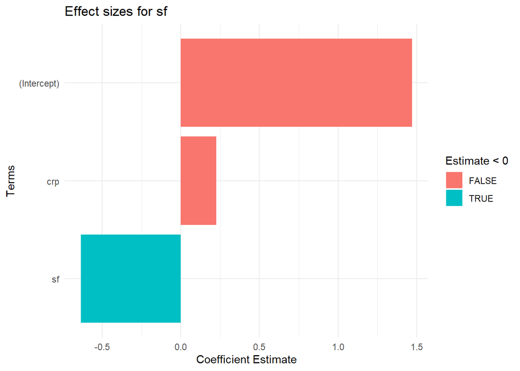

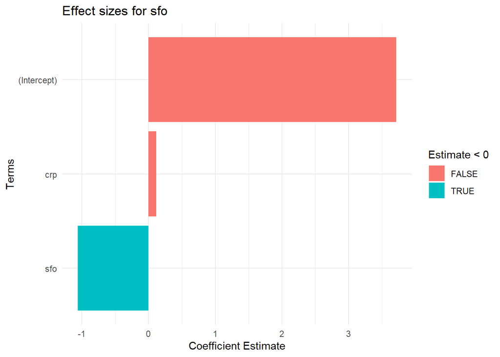

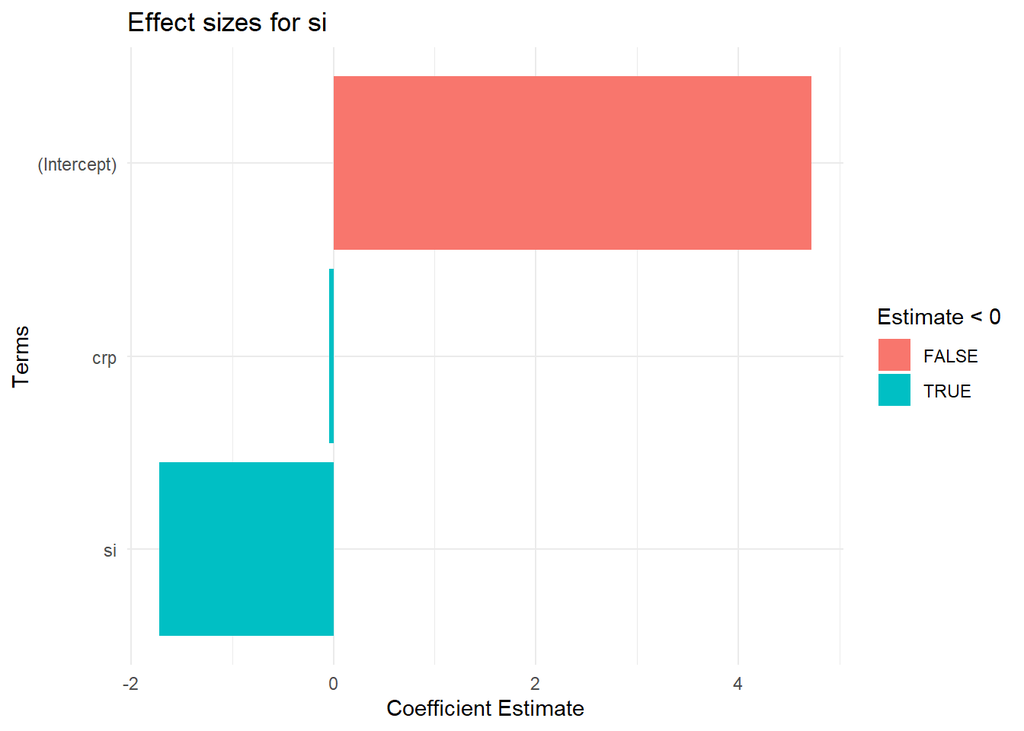

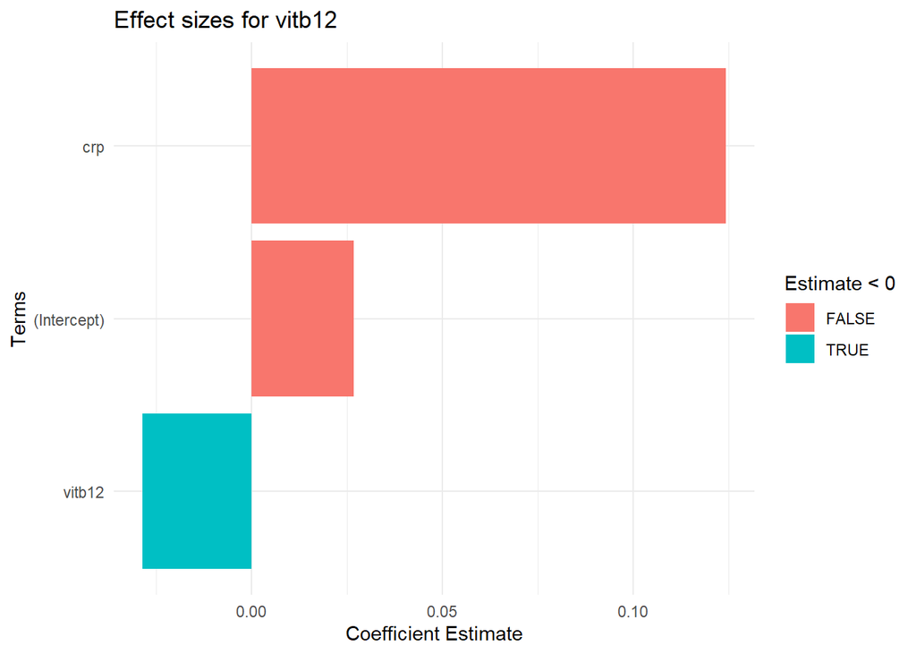

```r
for (micronutrient in micronutrients) {
    coef_df <- as.data.frame(coef(summary(results[[micronutrient]])))
    plot <- ggplot(coef_df, aes(x = reorder(rownames(coef_df), Estimate), y = Estimate, fill = Estimate < 0)) +
            geom_bar(stat = "identity") +
            coord_flip() +
            labs(title = paste("Effect sizes for", micronutrient), x = "Terms", y = "Coefficient Estimate") +
            theme_minimal()
    print(plot)
}
```

## Interaction

```r
data$anemia <- factor(data$anemia, levels = c(0, 1))
# Define the array of micronutrients and other covariates
micronutrients <- c("sf", "sfo", "si", "vitb12")
covariates <- c("age_yr", "BMI", "trimester", "gagewks")  # Clinical and demographic covariates

# Function to generate model formulas including interactions
generate_formula <- function(micronutrient) {
    main_effects <- paste(c("crp", micronutrient, covariates), collapse = " + ")
    interactions <- paste("crp", c(micronutrient, covariates), sep=":", collapse = " + ")
    full_formula <- paste("anemia ~", main_effects, "+", interactions)
    return(as.formula(full_formula))
}

# Loop through each micronutrient, build models, and store results
results <- list()

for (micronutrient in micronutrients) {
    cat("\nAnalyzing", micronutrient, "\n")

    # Generate the formula for the current micronutrient
    formula <- generate_formula(micronutrient)

    # Build the logistic regression model using binomial family
    model <- glm(formula, family = binomial(link = "logit"), data = data)

    # Store the model summary
    results[[micronutrient]] <- summary(model)

    # Print the summary to the console
    print(results[[micronutrient]])
}
```

```
##
## Analyzing sf
##
## Call:
## glm(formula = formula, family = binomial(link = "logit"), data = data)
##
## Coefficients:
##               Estimate Std. Error z value Pr(>|z|)
## (Intercept)    18.7473     6.5842   2.847  0.00441 **
## crp            -8.3918     3.1318  -2.680  0.00737 **
## sf             -0.7916     0.3218  -2.460  0.01390 *
## age_yr         -3.1045     1.3472  -2.304  0.02119 *
## BMI            -2.2740     1.5654  -1.453  0.14632
## trimester      -0.1658     0.8579  -0.193  0.84680
## gagewks         0.1631     1.2457   0.131  0.89585
## crp:sf          0.1312     0.1583   0.829  0.40709
## crp:age_yr      0.9319     0.6733   1.384  0.16634
## crp:BMI         1.1011     0.7136   1.543  0.12282
## crp:trimester  -0.1279     0.4133  -0.309  0.75697
## crp:gagewks     0.5563     0.6280   0.886  0.37565
## ---
## Signif. codes:  0 '***' 0.001 '**' 0.01 '*' 0.05 '.' 0.1 ' ' 1
##
## (Dispersion parameter for binomial family taken to be 1)
##
##     Null deviance: 625.18  on 479  degrees of freedom
## Residual deviance: 572.62  on 468  degrees of freedom
## AIC: 596.62
##
## Number of Fisher Scoring iterations: 4
##
##
## Analyzing sfo
##
## Call:
## glm(formula = formula, family = binomial(link = "logit"), data = data)
##
## Coefficients:
##               Estimate Std. Error z value Pr(>|z|)
## (Intercept)   17.57727    6.70369   2.622  0.00874 **
```

[output cut: 68 more lines]

```
## crp:vitb12     0.004221   0.354390   0.012  0.99050
## crp:age_yr     1.006494   0.657540   1.531  0.12584
## crp:BMI        0.768881   0.695169   1.106  0.26871
## crp:trimester -0.196275   0.409746  -0.479  0.63193
## crp:gagewks    0.580360   0.631060   0.920  0.35775
## ---
## Signif. codes:  0 '***' 0.001 '**' 0.01 '*' 0.05 '.' 0.1 ' ' 1
##
## (Dispersion parameter for binomial family taken to be 1)
##
##     Null deviance: 625.18  on 479  degrees of freedom
## Residual deviance: 589.34  on 468  degrees of freedom
## AIC: 613.34
##
## Number of Fisher Scoring iterations: 4
```

```r
# Evaluate and display significant interactions
for (micronutrient in micronutrients) {
    cat("\nResults for", micronutrient, ":\n")
    coef_summary <- coef(results[[micronutrient]])
    significant_interactions <- coef_summary[grepl("crp:", rownames(coef_summary)), "Pr(>|z|)"] < 0.05

    if (any(significant_interactions)) {
        cat("Significant interactions found for", micronutrient, ":\n")
        print(coef_summary[significant_interactions, , drop = FALSE])
    } else {
        cat("No significant interactions found for", micronutrient, "\n")
    }
}
```

```
##
## Results for sf :
## No significant interactions found for sf
##
## Results for sfo :
## No significant interactions found for sfo
##
## Results for si :
## No significant interactions found for si
##
## Results for vitb12 :
## No significant interactions found for vitb12
```

```r
# Visualize significant interactions if any
for (micronutrient in micronutrients) {
    if (any(results[[micronutrient]]$coefficients[grepl("crp:", names(results[[micronutrient]]$coefficients)), "Pr(>|z|)"] < 0.05)) {
        ggplot(data, aes_string(x = "crp", y = micronutrient, color = "factor(anemia)")) +
        geom_point(alpha = 0.5) +
        geom_smooth(method = "glm", method.args = list(family = "binomial"), formula = results[[micronutrient]]$call$formula, se = FALSE) +
        labs(title = paste("Effect of CRP and", micronutrient, "on Anemia"))
    }
}
```

# Aim 3

## Stepwise model

```r
model<-glm(anemia ~ si+sf+sfo+vitb12+trimester+gagewks+age_yr+crp+mstatus+tpreg+BMI,family = binomial(link="logit"),data=data_balanced)

step.model =stepAIC(model, direction="both")
```

```
## Start:  AIC=788.22
## anemia ~ si + sf + sfo + vitb12 + trimester + gagewks + age_yr +
##     crp + mstatus + tpreg + BMI
##
##             Df Deviance    AIC
## - tpreg     10   745.66 777.66
## - age_yr     1   736.33 786.33
## - crp        1   736.37 786.37
## - sf         1   736.68 786.68
## <none>           736.22 788.22
## - BMI        1   738.53 788.53
## - vitb12     1   740.10 790.10
## - mstatus    6   750.55 790.55
## - trimester  1   741.19 791.19
## - sfo        1   743.75 793.75
## - gagewks    1   755.70 805.70
## - si         1   784.58 834.58
##
## Step:  AIC=777.66
## anemia ~ si + sf + sfo + vitb12 + trimester + gagewks + age_yr +
##     crp + mstatus + BMI
##
##             Df Deviance    AIC
## - age_yr     1   745.67 775.67
## - crp        1   745.88 775.88
## - sf         1   746.63 776.63
## - BMI        1   747.52 777.52
## <none>           745.66 777.66
## - trimester  1   750.27 780.27
## - vitb12     1   750.60 780.60
## - sfo        1   753.17 783.17
## - mstatus    6   764.54 784.54
## + tpreg     10   736.22 788.22
## - gagewks    1   764.99 794.99
## - si         1   794.17 824.17
##
## Step:  AIC=775.67
## anemia ~ si + sf + sfo + vitb12 + trimester + gagewks + crp +
##     mstatus + BMI
##
```

[output cut: 34 more lines]

```
##     BMI
##
##             Df Deviance    AIC
## <none>           746.73 772.73
## - BMI        1   748.93 772.93
## + sf         1   745.89 773.89
## + crp        1   746.63 774.63
## + age_yr     1   746.73 774.73
## - vitb12     1   751.54 775.54
## - trimester  1   751.96 775.96
## - sfo        1   755.87 779.87
## + tpreg     10   736.94 782.94
## - mstatus    6   769.38 783.38
## - gagewks    1   771.76 795.76
## - si         1   807.69 831.69
```

```r
model_step<-glm(anemia ~ si + sfo + vitb12 + trimester + gagewks + mstatus + BMI,family = binomial(link="logit"),data=data_balanced)
summary(model_step)
```

```
##
## Call:
## glm(formula = anemia ~ si + sfo + vitb12 + trimester + gagewks +
##     mstatus + BMI, family = binomial(link = "logit"), data = data_balanced)
##
## Coefficients:
##              Estimate Std. Error z value Pr(>|z|)
## (Intercept)    1.4529     2.3540   0.617  0.53712
## si            -1.6545     0.2258  -7.326 2.37e-13 ***
## sfo           -0.6357     0.2131  -2.983  0.00285 **
## vitb12         0.3519     0.1780   1.977  0.04804 *
## trimester     -0.6711     0.2960  -2.267  0.02337 *
## gagewks        2.2769     0.4765   4.778 1.77e-06 ***
## mstatus1      -0.3474     0.3151  -1.103  0.27014
## mstatus2      13.9373  1029.1215   0.014  0.98919
## mstatus3     -15.7670   575.9802  -0.027  0.97816
## mstatus4      -0.3439     0.6272  -0.548  0.58344
## mstatus5       0.4809     0.3576   1.345  0.17878
## mstatus6       0.2408     0.4388   0.549  0.58323
## BMI           -0.6944     0.4699  -1.478  0.13943
## ---
## Signif. codes:  0 '***' 0.001 '**' 0.01 '*' 0.05 '.' 0.1 ' ' 1
##
## (Dispersion parameter for binomial family taken to be 1)
##
##     Null deviance: 900.80  on 650  degrees of freedom
## Residual deviance: 746.73  on 638  degrees of freedom
## AIC: 772.73
##
## Number of Fisher Scoring iterations: 14
```

```r
model_best<-glm(anemia ~ si + sfo + vitb12 + trimester + gagewks ,binomial(link="logit"),data=data_balanced)
summary(model_best)
```

```
##
## Call:
## glm(formula = anemia ~ si + sfo + vitb12 + trimester + gagewks,
##     family = binomial(link = "logit"), data = data_balanced)
##
## Coefficients:
##             Estimate Std. Error z value Pr(>|z|)
## (Intercept)  -0.3200     1.5803  -0.203 0.839510
## si           -1.6233     0.2195  -7.396 1.40e-13 ***
## sfo          -0.7544     0.2103  -3.587 0.000334 ***
## vitb12        0.4177     0.1851   2.256 0.024052 *
## trimester    -0.6145     0.2877  -2.136 0.032701 *
## gagewks       2.0170     0.4572   4.411 1.03e-05 ***
## ---
## Signif. codes:  0 '***' 0.001 '**' 0.01 '*' 0.05 '.' 0.1 ' ' 1
##
## (Dispersion parameter for binomial family taken to be 1)
##
##     Null deviance: 900.80  on 650  degrees of freedom
## Residual deviance: 770.98  on 645  degrees of freedom
## AIC: 782.98
##
## Number of Fisher Scoring iterations: 4
```

```r
model_bad<-glm(anemia~crp + mstatus + tpreg + BMI+age_yr+sf+trimester,family = binomial(link = "logit"),data=data_balanced)
summary(model_bad)
```

```
##
## Call:
## glm(formula = anemia ~ crp + mstatus + tpreg + BMI + age_yr +
##     sf + trimester, family = binomial(link = "logit"), data = data_balanced)
##
## Coefficients:
##               Estimate Std. Error z value Pr(>|z|)
## (Intercept)    5.02433    2.08632   2.408   0.0160 *
## crp            0.26007    0.12497   2.081   0.0374 *
## mstatus1      -0.15817    0.30896  -0.512   0.6087
## mstatus2      16.26167 1696.73440   0.010   0.9924
## mstatus3     -16.18096 1098.70481  -0.015   0.9882
## mstatus4       0.20256    0.62501   0.324   0.7459
## mstatus5       0.46908    0.34273   1.369   0.1711
## mstatus6       0.42790    0.41990   1.019   0.3082
## tpreg2        -0.12951    0.23711  -0.546   0.5849
## tpreg3         0.01226    0.24916   0.049   0.9608
## tpreg4         0.13053    0.29200   0.447   0.6549
## tpreg5         0.14299    0.43507   0.329   0.7424
## tpreg6         0.01515    0.56709   0.027   0.9787
## tpreg7         0.87813    0.85193   1.031   0.3027
## tpreg8        -0.26050    1.09934  -0.237   0.8127
## tpreg9        16.33452 1192.60864   0.014   0.9891
## tpreg10       16.33597 1696.73437   0.010   0.9923
## tpreg11       -0.14681 2639.12241   0.000   1.0000
## BMI           -0.32205    0.50011  -0.644   0.5196
## age_yr        -1.01577    0.54149  -1.876   0.0607 .
## sf            -0.53790    0.11115  -4.839  1.3e-06 ***
## trimester      0.22935    0.14801   1.549   0.1213
## ---
## Signif. codes:  0 '***' 0.001 '**' 0.01 '*' 0.05 '.' 0.1 ' ' 1
##
## (Dispersion parameter for binomial family taken to be 1)
##
##     Null deviance: 900.80  on 650  degrees of freedom
## Residual deviance: 813.73  on 629  degrees of freedom
## AIC: 857.73
##
## Number of Fisher Scoring iterations: 15
```

## Model evaluation

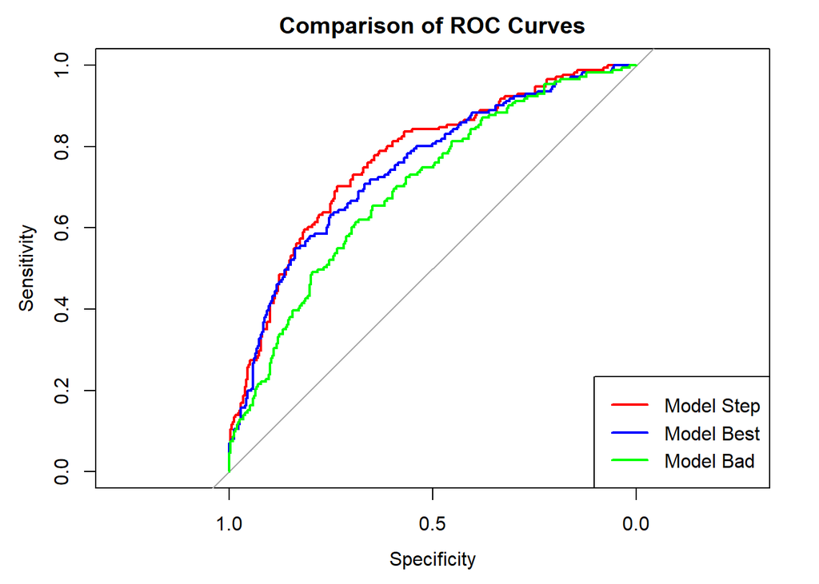

```r
# Calculate ROC objects
roc_step <- roc(response = data_balanced$anemia, predictor = fitted(model_step))
roc_best <- roc(response = data_balanced$anemia, predictor = fitted(model_best))
roc_bad <- roc(response = data_balanced$anemia, predictor = fitted(model_bad))

# Plotting all ROC curves together
plot(roc_step, main = "Comparison of ROC Curves", col = "red", print.auc = FALSE, print.auc.y = 0.2)
plot(roc_best, add = TRUE, col = "blue", print.auc = FALSE, print.auc.y = 0.4)
plot(roc_bad, add = TRUE, col = "green", print.auc = FALSE, print.auc.y = 0.6)

# Adding a legend to distinguish the models
legend("bottomright", legend = c("Model Step", "Model Best", "Model Bad"),
       col = c("red", "blue", "green"), lwd = 2)
```

```r
# Printing AUC scores separately
auc_step <- auc(roc_step)
auc_best <- auc(roc_best)
auc_bad <- auc(roc_bad)

print(paste("AUC for Model Step:", auc_step))
```

```
## [1] "AUC for Model Step: 0.768315070307916"
```

```r
print(paste("AUC for Model Best:", auc_best))
```

```
## [1] "AUC for Model Best: 0.746834724351331"
```

```r
print(paste("AUC for Model Bad:", auc_bad))
```

```
## [1] "AUC for Model Bad: 0.698158557126365"
```

it seems like the stepwise model is still the best model.

```r
glmtoolbox::hltest(model_step)
```

```
##
##    The Hosmer-Lemeshow goodness-of-fit test
##
##  Group Size Observed  Expected
##      1   66       10  8.929841
##      2   65       18 16.579754
##      3   65       24 22.303976
##      4   66       20 28.057390
##      5   65       30 32.148499
##      6   65       38 37.346535
##      7   66       46 42.698136
##      8   65       52 46.581451
##      9   65       50 51.009212
##     10   63       54 56.345206
##
##          Statistic =  8.80832
## degrees of freedom =  8
##            p-value =  0.35872
```

```r
glmtoolbox::hltest(model_best)
```

```
##
##    The Hosmer-Lemeshow goodness-of-fit test
##
##  Group Size Observed Expected
##      1   65       12 10.60729
##      2   66       20 18.34870
##      3   65       24 23.24654
##      4   65       26 28.03909
##      5   65       32 32.09117
##      6   65       30 36.38779
##      7   65       40 41.02322
##      8   66       52 46.65914
##      9   65       52 50.06533
##     10   64       54 55.53173
##
##          Statistic =  6.07119
## degrees of freedom =  8
##            p-value =  0.63926
```

```r
glmtoolbox::hltest(model_bad)
```

```
##
##    The Hosmer-Lemeshow goodness-of-fit test
##
##  Group Size Observed Expected
##      1   65       12 13.58599
##      2   65       22 21.83615
##      3   66       30 27.16977
##      4   65       28 30.18253
##      5   66       34 33.76319
##      6   65       36 36.29874
##      7   65       40 39.28407
##      8   65       44 42.02170
##      9   65       46 45.69413
##     10   64       50 52.16372
##
##          Statistic =  1.82924
## degrees of freedom =  8
##            p-value =  0.98581
```

These models fit well.

## Alternative way

### Feature selection

```r
data_balanced$anemia <- factor(data_balanced$anemia, levels = c(0, 1))

set.seed(123)
index <- createDataPartition(data_balanced$anemia, p = 0.8, list = FALSE)
train_data <- data_balanced[index, ]
test_data <- data_balanced[-index, ]

set.seed(7) # For reproducibility
outcomeVar <- "anemia"
predictorVars <- setdiff(names(train_data), outcomeVar)

# Define the control using a repeated cross-validation approach
control <- rfeControl(functions = rfFuncs, method = "cv", number = 10)

# Run the RFE algorithm
results <- rfe(train_data[, predictorVars], train_data[, outcomeVar],
               sizes = c(1:length(predictorVars)), rfeControl = control)

# Summarize the results
print(results)
```

```
##
## Recursive feature selection
##
## Outer resampling method: Cross-Validated (10 fold)
##
## Resampling performance over subset size:
##
##  Variables Accuracy  Kappa AccuracySD KappaSD Selected
##          1   0.6731 0.3420    0.08313 0.16878
##          2   0.7588 0.5128    0.04165 0.08434
##          3   0.7836 0.5627    0.03867 0.07952
##          4   0.7947 0.5849    0.03637 0.07476
##          5   0.8218 0.6413    0.03173 0.06351
##          6   0.8179 0.6330    0.04011 0.08080
##          7   0.8141 0.6255    0.06031 0.12316
##          8   0.8219 0.6415    0.04556 0.09121
##          9   0.8275 0.6526    0.05441 0.11053        *
##         10   0.8200 0.6373    0.06756 0.13619
##         11   0.8219 0.6417    0.04903 0.09848
##
## The top 5 variables (out of 9):
##    si, sfo, sf, vitb12, gagewks
```

```r
# List the chosen features
chosen_predictors <- predictors(results)
print(chosen_predictors)
```

```
## [1] "si"      "sfo"     "sf"      "vitb12"  "gagewks" "crp"     "age_yr"
## [8] "BMI"     "mstatus"
```

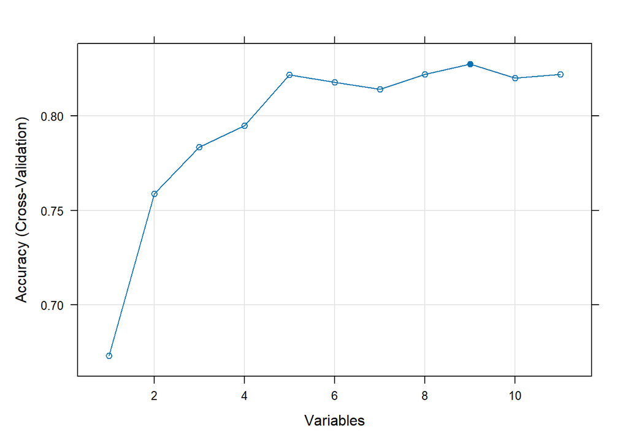

```r
# Plot the RFE performance
plot(results, type = c("g", "o"))
```

```r
#control <- trainControl(method="repeatedcv", number=10, repeats=3, search="grid")

# Train the model with variable selection using LASSO
#set.seed(7)
#model <- train(anemia ~ si+sf+sfo+vitb12+trimester+gagewks+age_yr+crp+mstatus+tpreg+BMI, data=train_data,method="glmnet",trControl=control,tuneLength=5,family="binomial")
# Check the results
#print(model)
#plot(varImp(model), top=11)
```

The max number of the model should be 9 and top 5 variables are si, sfo, sf, vitb12, gagewks.

```r
set.seed(123)
index <- createDataPartition(data_balanced$anemia, p = 0.8, list = FALSE)
train_data <- data_balanced[index, ]
test_data <- data_balanced[-index, ]

# Ensure the outcome variable is a factor with appropriate levels
train_data$anemia <- factor(train_data$anemia, levels = c(0, 1))

# Fit a logistic regression model to the training data
model <- glm(anemia ~ si+sfo+sf+vitb12+gagewks+crp+age_yr+BMI+mstatus,
             family = binomial(link = "logit"), data = train_data)

# Obtain predicted probabilities from the model
train_predictions_model <- predict(model, type = "response", newdata = train_data)

# Convert probabilities to binary class predictions
train_predicted_class <- ifelse(train_predictions_model > 0.5, 1, 0)
train_predicted_class <- factor(train_predicted_class, levels = c(0, 1))

# Generate a confusion matrix to see how well the model performs on the training data
confusion_matrix <- confusionMatrix(train_predicted_class, train_data$anemia)
print(confusion_matrix)
```

```
## Confusion Matrix and Statistics
##
##           Reference
## Prediction   0   1
##          0 168  71
##          1  80 203
##
##                Accuracy : 0.7107
##                  95% CI : (0.6698, 0.7493)
##     No Information Rate : 0.5249
##     P-Value [Acc > NIR] : <2e-16
##
##                   Kappa : 0.419
##
##  Mcnemar's Test P-Value : 0.515
##
##             Sensitivity : 0.6774
##             Specificity : 0.7409
##          Pos Pred Value : 0.7029
##          Neg Pred Value : 0.7173
##              Prevalence : 0.4751
##          Detection Rate : 0.3218
##    Detection Prevalence : 0.4579
##       Balanced Accuracy : 0.7091
##
##        'Positive' Class : 0
##
```

```r
set.seed(123)
# Ensure consistent use of dataset
index <- createDataPartition(data_balanced$anemia, p = 0.8, list = FALSE)
train_data <- data_balanced[index, ]
test_data <- data_balanced[-index, ]

# Ensure the outcome variable in the test data is a factor
test_data$anemia <- factor(test_data$anemia, levels = c(0, 1))

test_predictions_model <- predict(model, type = "response", newdata = test_data)

# Convert probabilities to binary class predictions and factorize
test_predicted_class <- ifelse(test_predictions_model > 0.5, 1, 0)
test_predicted_class <- factor(test_predicted_class, levels = c(0, 1))

# Evaluate the model performance on the test data
conf_matrix <- confusionMatrix(test_predicted_class, test_data$anemia)
print(conf_matrix)
```

```
## Confusion Matrix and Statistics
##
##           Reference
## Prediction  0  1
##          0 38 21
##          1 23 47
##
##                Accuracy : 0.6589
##                  95% CI : (0.5703, 0.7401)
##     No Information Rate : 0.5271
##     P-Value [Acc > NIR] : 0.001659
##
##                   Kappa : 0.3147
##
##  Mcnemar's Test P-Value : 0.880168
##
##             Sensitivity : 0.6230
##             Specificity : 0.6912
##          Pos Pred Value : 0.6441
##          Neg Pred Value : 0.6714
##              Prevalence : 0.4729
##          Detection Rate : 0.2946
##    Detection Prevalence : 0.4574
##       Balanced Accuracy : 0.6571
##
##        'Positive' Class : 0
##
```

```r
set.seed(123)
index <- createDataPartition(data_balanced$anemia, p = 0.8, list = FALSE)
train_data <- data_balanced[index, ]
test_data <- data_balanced[-index, ]

# Ensure the outcome variable is a factor with appropriate levels
train_data$anemia <- factor(train_data$anemia, levels = c(0, 1))

# Fit a logistic regression model to the training data
model_step<-glm(anemia ~ si + sfo + vitb12 + trimester + gagewks + mstatus + BMI,family = binomial(link="logit"),data=train_data)

# Obtain predicted probabilities from the model
train_predictions_step <- predict(model_step, type = "response", newdata = train_data)

# Convert probabilities to binary class predictions
train_predicted_class <- ifelse(train_predictions_step > 0.5, 1, 0)
train_predicted_class <- factor(train_predicted_class, levels = c(0, 1))

# Generate a confusion matrix to see how well the model performs on the training data
confusion_matrix <- confusionMatrix(train_predicted_class, train_data$anemia)
print(confusion_matrix)
```

```
## Confusion Matrix and Statistics
##
##           Reference
## Prediction   0   1
##          0 168  72
##          1  80 202
##
##                Accuracy : 0.7088
##                  95% CI : (0.6678, 0.7475)
##     No Information Rate : 0.5249
##     P-Value [Acc > NIR] : <2e-16
##
##                   Kappa : 0.4153
##
##  Mcnemar's Test P-Value : 0.5702
##
##             Sensitivity : 0.6774
##             Specificity : 0.7372
##          Pos Pred Value : 0.7000
##          Neg Pred Value : 0.7163
##              Prevalence : 0.4751
##          Detection Rate : 0.3218
##    Detection Prevalence : 0.4598
##       Balanced Accuracy : 0.7073
##
##        'Positive' Class : 0
##
```

```r
set.seed(123)
# Ensure consistent use of dataset
index <- createDataPartition(data_balanced$anemia, p = 0.8, list = FALSE)
train_data <- data_balanced[index, ]
test_data <- data_balanced[-index, ]

# Ensure the outcome variable in the test data is a factor
test_data$anemia <- factor(test_data$anemia, levels = c(0, 1))

# Assuming 'model' is already trained using train_data as shown in previous examples
test_predictions_step <- predict(model_step, type = "response", newdata = test_data)

# Convert probabilities to binary class predictions and factorize
test_predicted_class <- ifelse(test_predictions_step > 0.5, 1, 0)
test_predicted_class <- factor(test_predicted_class, levels = c(0, 1))

# Evaluate the model performance on the test data
conf_matrix <- confusionMatrix(test_predicted_class, test_data$anemia)
print(conf_matrix)
```

```
## Confusion Matrix and Statistics
##
##           Reference
## Prediction  0  1
##          0 36 20
##          1 25 48
##
##                Accuracy : 0.6512
##                  95% CI : (0.5623, 0.7329)
##     No Information Rate : 0.5271
##     P-Value [Acc > NIR] : 0.002927
##
##                   Kappa : 0.2973
##
##  Mcnemar's Test P-Value : 0.550985
##
##             Sensitivity : 0.5902
##             Specificity : 0.7059
##          Pos Pred Value : 0.6429
##          Neg Pred Value : 0.6575
##              Prevalence : 0.4729
##          Detection Rate : 0.2791
##    Detection Prevalence : 0.4341
##       Balanced Accuracy : 0.6480
##
##        'Positive' Class : 0
##
```

### AUC and ROC for train

```r
# ROC and AUC for model
roc_obj1 <- roc(response = train_data$anemia, predictor = train_predictions_model)
auc_value1 <- auc(roc_obj1)

# ROC and AUC for model_step
roc_obj2 <- roc(response = train_data$anemia, predictor = train_predictions_step)
auc_value2 <- auc(roc_obj2)

# Print AUC values
print(paste("AUC for Model :", auc_value1))
```

```
## [1] "AUC for Model : 0.757829055804097"
```

```r
print(paste("AUC for Model_step:", auc_value2))
```

```
## [1] "AUC for Model_step: 0.761346244407817"
```

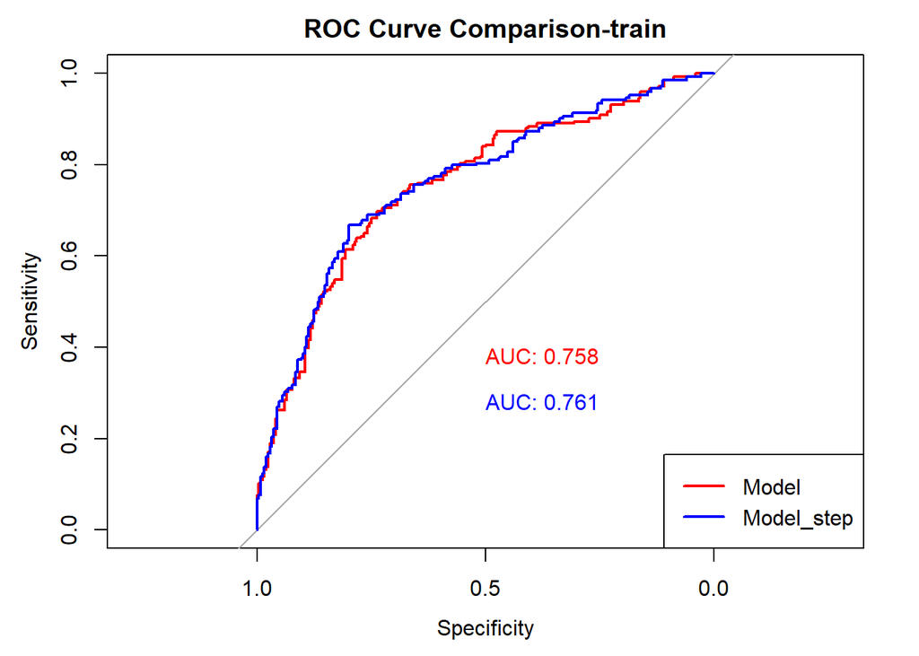

```r
# Plot both ROC curves on the same plot
plot(roc_obj1, main="ROC Curve Comparison-train", col="red", print.auc=TRUE, print.auc.y=0.4)
plot(roc_obj2, add=TRUE, col="blue", print.auc=TRUE, print.auc.y=0.3)

# Adding a legend to distinguish the models
legend("bottomright", legend=c("Model ", "Model_step"), col=c("red", "blue"), lwd=2)
```

### AUC and ROC for test

```r
# ROC and AUC for model
roc_obj1 <- roc(response = test_data$anemia, predictor = test_predictions_model)
auc_value1 <- auc(roc_obj1)

# ROC and AUC for model_step
roc_obj2 <- roc(response = test_data$anemia, predictor = test_predictions_step)
auc_value2 <- auc(roc_obj2)

# Print AUC values
print(paste("AUC for Model :", auc_value1))
```

```
## [1] "AUC for Model : 0.73023143683703"
```

```r
print(paste("AUC for Model_step:", auc_value2))
```

```
## [1] "AUC for Model_step: 0.727338476374156"
```

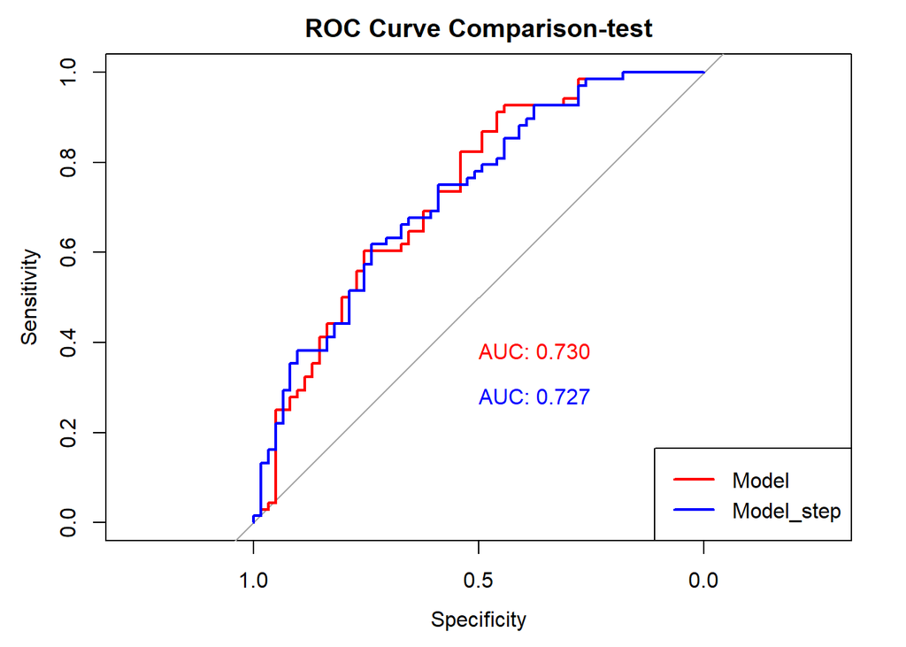

```r
# Plot both ROC curves on the same plot
plot(roc_obj1, main="ROC Curve Comparison-test", col="red", print.auc=TRUE, print.auc.y=0.4)
plot(roc_obj2, add=TRUE, col="blue", print.auc=TRUE, print.auc.y=0.3)

# Adding a legend to distinguish the models
legend("bottomright", legend=c("Model ", "Model_step"), col=c("red", "blue"), lwd=2)
```

```r
glmtoolbox::hltest(model)
```

```
##
##    The Hosmer-Lemeshow goodness-of-fit test
##
##  Group Size Observed  Expected
##      1   53       13  9.043729
##      2   52       16 13.227205
##      3   53       10 17.677179
##      4   52       24 21.758487
##      5   53       20 26.283318
##      6   52       30 30.052074
##      7   52       36 33.581138
##      8   52       41 36.740372
##      9   52       39 40.391228
##     10   51       45 45.245268
##
##          Statistic =  13.64744
## degrees of freedom =  8
##            p-value =  0.09143
```

```r
glmtoolbox::hltest(model_step)
```

```
##
##    The Hosmer-Lemeshow goodness-of-fit test
##
##  Group Size Observed  Expected
##      1   52       13  8.439027
##      2   52       13 13.720561
##      3   52       21 17.326013
##      4   52       13 21.059680
##      5   53       22 25.882214
##      6   53       28 30.009185
##      7   52       39 33.247388
##      8   52       40 37.258875
##      9   52       39 41.125412
##     10   52       46 45.931645
##
##          Statistic =  14.79205
## degrees of freedom =  8
##            p-value =  0.063317
```

The model-glm(anemia ~ si+sfo+sf+vitb12+gagewks+crp+age_yr+BMI+mstatus) turns out to be the best model for it has higer AUC socre in test performance and max number of variables in the model is 9. Both models fit well.